# NOAA API & PHILADELPHIA WEATHER PREDICTION

[output not shown]

# NOAA API & PHILADELPHIA WEATHER PREDICTION

**Team Member:**

**Thu Tran**: I have extensive experience as a web developer from earlier in my career. Recently, I graduated from Drexel University with a degree in Chemical Engineering, and I am currently pursuing a Master's degree in Data Science. Throughout my diverse career, I have developed a robust skill set that allows me to contribute significantly in various roles. My experiences have enabled me to effectively manage projects, conduct in-depth research, process and analyze data, and create insightful visualizations. This unique combination of skills from different fields allows me to approach problems from multiple perspectives and deliver comprehensive solutions.

**Joe Novak**: I hold a bachelors degree in design and am currently working as an associate data science analyst at a large healthcare institute supporting computation work of Principal Investigators in the domain of Lymphoma cancers. I have experience with large-cohort patient clinical data, whole-exome sequencing (WES) data, and RNAseq data. Data manipulation, hypothesis testing, and data visualization are all concepts which I would be comfortable using. At the same time, I'm enrolled in Drexel's Online Master of Data Science program. From this project I'd like to learn more about the data analysis process and how to communicate results to an audience.

# **Our Topic**:

The topic we pick is weather analysis. We created some brainstoming questions what, how, why, where, when... to know what we need to analyze:

1. Where we can find free datasource: We found some datasource that provide current weather and historical weather :
   - The **National Oceanic and Atmospheric Association** (**NOAA**) is an agency within the US Department of Commerce focused on keeping the public informed on current climate conditions. NOAA is rigourously committed to scientific integrity and oversees an umbrella of smaller focused agencies
   - **National Weather Service** (**NWS**) is an agency within NOAA and maintains an API to provide current weather : https://api.weather.gov -The **Applied Climate Information System** (**ACIS**) is maintained and developed by NOAA's **Regional Climate Centers** (**RCC**). This API provides access to historical weather data: http://data.rcc-acis.org
   - NOAA provides Philadelphia monthly maximum/average/minimum temperature from 1895 to 2023 through ACIS API at: https://www.weather.gov/wrh/Climate?wfo=phi
1. How we extract data from that dataset: We use Python to make requests of API to source JSON format data and download CSV files from NOAA. In the previous phase, data from OpenWeatherMap's API was used. The system only allowed 1000 daily requests, creating a challenging to analyze and show the data. Therefore, the analysis was lifted over to NOAA datasets. The system restrictions are more relaxed. Ultimately, this change results in a more reliable tool.
1. How do we know the accuracy for our extracting dataset: API from NOAA is the best accurate information maintained by the US government. The agency has established an extensive library and research department meriting observations. After analysis and investigation, we could compare our predicted model and NOAA data point.
1. What specific data do we need for analysis: Airport International Civil Aviation Organization (ICAO) airport identifiers. Monthly average temperature, current temperature, latitude and longitude, and US state code will be necessary for each location. As a proxy for statewide values, we will be using observations from major airports in each state, prioritizing capital cities and international airports. ICAO identifiers will be used to query each location. The monthly average temperature is computed as the mean of average temperature for each calendar month. To observe longer-term trends we will search for data from 1895 to the present.
1. What specific aspect of data visualization:
   - Current temperature for each state in US
   - Temperature trend for each state from 1895 to 2023
   - Temperature trend for monthly Philadelphia from 1895 to 2023
   - Temperature trend for yealy Philadelphia from 1895 to 2150
2. How we can use the specific data to generate predicted topic: Base on the dataset trend, we can predict the overall temperature for each state in the the US. We also predict the monthly/yearly temperature for Philadelphia.
1. What is limit or future research: We want to investigate 100 years of climate change in Philadelphia and the other big cities in the US. However, API costs some money for accessibility. This project is beneficial for all industrial manufacturing companies. We wish we had enough time and an unlimited dataset to calculate and predict for all city and US states.

```python
import requests
	import urllib.request
	import urllib.error
	import pandas as pd
	import numpy as np
	import matplotlib.pyplot as plt
	import plotly.graph_objects as go
	import seaborn as sns
	import json
	from scipy import stats
	from sklearn.metrics import mean_squared_error
	from statsmodels.tsa.arima.model import ARIMA
	import datetime
	import warnings
	warnings.filterwarnings('ignore')
```

# **Dataset Exploration**

Using NWSs current weather API and ACISs historical API, we will breifly explore past and present climate data in the US.

1. Python's requests package will be used to access NOAA's APIs, querying by ICAO identifier.
2. Historical temperature data freely available from ACIS API
3. NOAA historial maximum/minumum/average data of Philadelphia in csv format.

**Airport proxies for state analysis**

Our goal is to investigate statewide and countrywide temperature patterns across the US. For this analysis we need monthly average temperature for each state. To capture a true state average is not feasible, as weather sensors are spaced across states, providing a granular picture of reality, and is beyond the scope of this project. So, we decided to use one major airport from each state as a proxy or pseudotemperature representing the political boundary. Here are the list of ICAO identifiers for each airport chosen:

```python
ports=[["AL","KBHM"],["AK","PAJN"],["AZ","KPHX"],["AR","KLIT"],["CA","KSMF"],["CO","KDEN"],["CT","KBDL"],["DE","KILG"],["FL","KTLH"],["GA","KATL"],["HI","PHNL"],["ID","KBOI"],["IL","KORD"],["IN","KIND"],["IA","KDSM"],["KS","KICT"],["KY","KLEX"],["LA","KMSY"],["ME","KBGR"],["MD","KBWI"],["MA","KBOS"],["MI","KLAN"],["MN","KMSP"],["MS","KJAN"],["MO","KSTL"],["MT","KBIL"],["NE","KLNK"],["NV","KLAS"],["NH","KPSM"],["NJ","KTTN"],["NM","KABQ"],["NY","KALB"],["NC","KRDU"],["ND","KBIS"],["OH","KCMH"],["OK","KTUL"],["OR","KPDX"],["PA","KMDT"],["RH","KPVD"],["SC","KCAE"],["SD","KPIR"],["TN","KBNA"],["TX","KAUS"],["UT","KSLC"],["VT","KBTV"],["VA","KRIC"],["WA","KSEA"],["WV","KCRW"],["WI","KMSN"],["WY","KCPR"]]
```

## **1. NWS API Latest Observations**

In this section we demonstrate the use of api.weather.gov to fetch current weather obervations for a location.

**getAirportDataCurrent()** requires a list of list as input. The input provides state and airport information necessary to retreive current data.

example:

ports = [["PA","KMDT"],["MN","KMSP"]]

getAirportDataCurrent(airports=ports)

Will return current temperature data for Harrisburg International Airport and Minneapolis–Saint Paul International Airport which we use to represent each respective state

```python
#NOAA API
	#authorization for API use
	my_headers = {'User-Agent' : 'jn875@drexel.edu'}

	def getAirportDataCurrent(airports=[]):
	  map_data = []
	  for i in airports:
		observation_request = f"https://api.weather.gov/stations/{i[1]}/observations/latest"
		#station_request = f"https://api.weather.gov/stations/{i[1]}"
		observation_data = requests.get(observation_request,headers=my_headers).json()
		#station_data = requests.get(station_request,headers=my_headers).json()

		#if there is no reading, leave it as an NA value
		if(observation_data["properties"]["temperature"]["value"] is None):
			temp = observation_data["properties"]["temperature"]["value"]
		#if there is a current reading, transform it to Fahrenheit
		else:
			temp =observation_data["properties"]["temperature"]["value"]*1.8+32

		map_data.append([i[0],temp,observation_data["geometry"]["coordinates"][0],observation_data["geometry"]["coordinates"][1],observation_data['properties']['timestamp']])
	  return map_data
```

- NWS current API response provides rich data for each location. Each observation is generated by FAA certified Automated Weather Observation System (AWOS) station and comes from sensors at the location. Since this work is funded by public tax dollars the agency is obligated to make data available. This results in very organized and detailed weather data used by weather professionals daily.
- "geometry" key provides location in latitude and longitude
- "properties" key provides many relevant current values:
  - Temperature in Celcius
  - Dewpoint in Celcius
  - Wind direction in angle
  - Wind speed in km/h
  - Barometric pressure in Pa
  - Visibility in m
  - Timestamp
  - and more...

  Here we demonstrate the retrival of current temperature in Pennsylvania

```python
#Using this API users can generate useful queries for specific locations
	observation_request = f"https://api.weather.gov/stations/KMDT/observations/latest"
	observation_data = requests.get(observation_request,headers=my_headers).json()
	print(json.dumps(observation_data,indent=2))
	print("Latest temperature at KMDT", observation_data['properties']['temperature']['value'],"C")
```

[output not shown]

[output cut: 108 more lines]

[output not shown]

## **2. ACIS API Historical Temperature Data**

Two functions makeRequest(url,params) and getAirportDataHistorical(airports) are defined for requesting data from the ACIS API.

**makeRequest()** uses the base url and specific API paremeters to make a request for a location. Once the request is made the function loads and returns the request in the json format.

**getAirportDataHistorical()** implements makeRequest to build a dataset for multiple locations and returns a nested list. This function contains a dictionary of parameters for the API. Those parameters request monthly average temperature from 1895 to 2023

```python
#Function request to acis database
	def makeRequest(url,params) :
		req = urllib.request.Request(url,
		json.dumps(params).encode('utf-8'),
		{"Content-Type":"application/json"})
		response = urllib.request.urlopen(req)
		try:
			response = urllib.request.urlopen(req)
			return json.loads(response.read())
		except urllib.error.HTTPError as error:
			if error.code == 400 : print(error.msg)

	base_url = "http://data.rcc-acis.org/"

	#parameters for the monthly average temperature of location from 1895-01-01 to 2023-7-31
	def getAirportDataHistorical(airports=[]):
		outputs=list()
		for i in airports:
			input={"sid":i[1],"edate":"2023-07-31","elems":[{"name":"avgt","interval":"mly","reduce":"mean"}],"sdate":"1895-01-01",'output':'json'}
			temp=makeRequest(base_url+"StnData",input)
			outputs.append([temp])
		return outputs
```

In this example we see a snippet of retreived data for MSP airport. Data is missing until April 1938 when this location started collecting observations. "M" values were transformed to nan and removed when conducting subsequent analysis.

```python
getAirportDataHistorical([["MN","KMSP"]])[0][0]['data'][515:525]
```

```
[['1937-12', 'M'],
	 ['1938-01', 'M'],
	 ['1938-02', 'M'],
	 ['1938-03', 'M'],
	 ['1938-04', '46.00'],
	 ['1938-05', '56.71'],
	 ['1938-06', '67.90'],
	 ['1938-07', '73.44'],
	 ['1938-08', '73.82'],
	 ['1938-09', '62.22']]
```

## **3. NOAA historial maximum/minumum/average data of Philadelphia**

```python
#from google.colab import drive
	#drive.mount('/content/drive')
	#max_data_Phila = pd.read_csv("/content/drive/MyDrive/Jupiter/project-2/maxTempPhila.csv",index_col=0)
	max_data_Phila = pd.read_csv("./maxTempPhila.csv",index_col=0)
	#historical_maximum_data_Phila
	print(max_data_Phila.shape)
	print(max_data_Phila.head())
```

```
(129, 12)
		  jan  feb  mar  apr  may  jun  jul  aug   sep   oct   nov   dec
	year
	1895   55   53   64   84   94   97   94   98  97.0  74.0  74.0  66.0
	1896   53   60   63   93   93   91   93   97  92.0  74.0  73.0  60.0
	1897   61   53   68   85   82   91   94   90  96.0  88.0  71.0  63.0
	1898   58   61   72   78   91   94  100   93  96.0  83.0  66.0  60.0
	1899   56   57   70   80   89   97   96   95  87.0  80.0  65.0  65.0
```

This minimum temperature dataset has the same structure as the maximum temperature dataset. It spans from 1895 to 2023, with the first column representing the years. The other columns indicate the minimum temperature for each month of the corresponding year.

```python
#min_data_Phila = pd.read_csv("/content/drive/MyDrive/Jupiter/project-2/minTempPhila.csv",index_col=0)
	min_data_Phila = pd.read_csv("./minTempPhila.csv",index_col=0)
	#historical_minimum_data_Phila
	print(min_data_Phila.head())
```

```
      jan  feb  mar  apr  may  jun  jul  aug   sep   oct   nov   dec
	year
	1895   10   -3   18   32   40   54   57   56  45.0  34.0  26.0  13.0
	1896    4   -2   15   28   45   54   61   56  44.0  37.0  29.0  12.0
	1897    7   18   23   27   46   49   63   62  45.0  39.0  24.0  16.0
	1898   12    8   25   25   40   53   57   60  51.0  35.0  26.0  16.0
	1899    6   -6   23   28   45   58   60   58  45.0  34.0  29.0   8.0
```

This average temperature dataset has the same structure as the previous datasets. It covers the period from 1895 to 2023, with the first column representing the years. The remaining columns indicate the average temperature for each month of the corresponding year.

```python
#average_data_Phila = pd.read_csv("/content/drive/MyDrive/Jupiter/project-2/averageTempPhila.csv",index_col=0)
	average_data_Phila = pd.read_csv("./averageTempPhila.csv",index_col=0)
	#historical_average_data_Phila
	print(average_data_Phila.head())
```

```
       jan   feb   mar   apr   may   jun   jul   aug   sep   oct   nov   dec
	year
	1895  30.4  25.4  37.9  51.7  62.2  74.1  73.3  77.5  72.3  52.6  46.5  38.9
	1896  31.0  33.6  35.9  55.3  67.2  70.3  77.5  76.6  67.8  53.6  50.4  34.7
	1897  30.8  35.3  43.1  52.7  62.7  68.9  76.4  74.4  68.4  58.3  45.9  38.1
	1898  35.3  35.6  48.0  49.5  61.2  72.4  78.2  76.8  71.4  58.6  44.6  35.9
	1899  32.3  28.1  40.7  53.4  63.3  74.9  76.7  74.8  67.0  58.6  46.3  37.5
```

# **Interested Analysis Area**

Our interesting area for weather analysis are:

## **1. Current weather of each US State**

In order to get current pseudotemperature for US states we invoke the getAirportDataCurrent function with our list of states and airports as input.

```python
current_dat = getAirportDataCurrent(airports=ports)
	current_dat[0:5]
```

```
[['AL', 84.92, -86.75, 33.57, '2024-06-08T17:53:00+00:00'],
	 ['AK', 62.06, -134.58, 58.37, '2024-06-08T17:53:00+00:00'],
	 ['AZ', 98.06, -112.02, 33.43, '2024-06-08T17:51:00+00:00'],
	 ['AR', 84.02, -92.23, 34.72, '2024-06-08T17:53:00+00:00'],
	 ['CA', 73.03999999999999, -121.58, 38.7, '2024-06-08T17:53:00+00:00']]
```

Then, python package Pandas is used to format as DataFrame

```python
map_data_current = pd.DataFrame(current_dat, columns = ["state","temp","lat","lon",'timestamp'])
	map_data_current.head()
```

|  | state | temp | lat | lon | timestamp |
| --- | --- | --- | --- | --- | --- |
| 0 | AL | 84.92 | -86.75 | 33.57 | 2024-06-08T17:53:00+00:00 |
| 1 | AK | 62.06 | -134.58 | 58.37 | 2024-06-08T17:53:00+00:00 |
| 2 | AZ | 98.06 | -112.02 | 33.43 | 2024-06-08T17:51:00+00:00 |
| 3 | AR | 84.02 | -92.23 | 34.72 | 2024-06-08T17:53:00+00:00 |
| 4 | CA | 73.04 | -121.58 | 38.70 | 2024-06-08T17:53:00+00:00 |

```python
#this code will take a minute or two
	historical = getAirportDataHistorical(ports)
```

```python
rows = [i[0] for i in historical[0][0]['data']]
	historical_data = pd.DataFrame(index=rows)

	count = 0
	for i in historical:
		temp = pd.DataFrame([x[1] for x in  i[0]['data']])
		historical_data[ports[count][1]]= [x[1] for x in i[0]['data']]
		count+=1
	historical_data = historical_data.replace("M",np.nan)
	historical_data.index = pd.to_datetime(historical_data.index)

	#print(historical_data.min().name)
```

```python
numeric = historical_data.to_numpy()

	#remove the null observation for analysis
	vals=[i[~pd.isnull(i)] for i in numeric]

	vals=[float(item) for sublist in vals for item in sublist]

	print("% missing values since 1895:",len(vals)/len(historical_data))
	print("highest monthly avgt:",max(vals))
	print("lowest monthly avgt:",min(vals))
```

```
% missing values since 1895: 30.684381075826312
	highest monthly avgt: 102.74
	lowest monthly avgt: -11.4
```

## **3. Monthly Highest/Average/Lowest temperature in Philadelphia in 1895 to 2023**

We have a dataset containing monthly temperatures for each year. Initially, it was challenging to calculate and plot the data points due to the arrangement of months and years. To address this, we used the "transpose" function to reverse the data frame, making it easier to work with. The transformed dataset is shown below:

```python
new_average_data_Phila= average_data_Phila.transpose()
	print(new_average_data_Phila.head())
```

```
year  1895  1896  1897  1898  1899  1900  1901  1902  1903  1904  ...  2014  \
	jan   30.4  31.0  30.8  35.3  32.3  34.8  33.1  31.3  32.7  25.9  ...  28.3
	feb   25.4  33.6  35.3  35.6  28.1  32.4  27.1  29.7  36.5  27.4  ...  32.1
	mar   37.9  35.9  43.1  48.0  40.7  37.5  41.8  46.3  49.4  39.4  ...  38.9
	apr   51.7  55.3  52.7  49.5  53.4  53.7  50.1  52.6  53.3  49.1  ...  53.8
	may   62.2  67.2  62.7  61.2  63.3  63.0  60.5  62.5  65.6  65.5  ...  65.4

	year  2015  2016  2017  2018  2019  2020  2021  2022  2023
	jan   30.9  34.2  38.5  32.8  33.3  38.9  35.7  32.4  43.3
	feb   25.8  38.6  44.2  41.9  37.1  40.8  34.2  39.7  42.7
	mar   39.1  51.0  42.1  40.1  42.8  48.9  47.4  47.8  45.1
	apr   55.4  54.5  59.5  50.4  59.0  51.6  55.6  54.0  58.3
	may   70.1  63.0  63.1  67.7  66.4  61.4  64.1  67.5  62.4

	[5 rows x 129 columns]
```

We also added three additional columns to the dataset to calculate the maximum, minimum, and mean temperatures for each month across all years from 1895 to 2023. These columns are named to reflect their respective calculations and the average temperature dataset they belong to:

1. Maximum value of the average temperature dataset = AverageUpperLimit
2. Minimum value of the average temperature dataset = AverageLowerLimit
3. Average value of the average temperature dataset = AverageAverageLimit

```python
#ADD MAX, MIN, AVERAGE COLUMN
	new_average_data_Phila = new_average_data_Phila.assign(AverageUpperLimit=new_average_data_Phila.max(axis=1),AverageLowerLimit=new_average_data_Phila.min(axis=1),AverageAverageLimit=new_average_data_Phila.mean(axis=1).round())
	print(new_average_data_Phila.iloc[:,-3:])
```

```
year  AverageUpperLimit  AverageLowerLimit  AverageAverageLimit
	jan                46.2               20.0                 33.0
	feb                44.2               22.2                 34.0
	mar                52.5               32.6                 43.0
	apr                59.5               46.8                 53.0
	may                70.8               55.9                 64.0
	jun                78.2               65.8                 72.0
	jul                82.4               72.0                 77.0
	aug                81.3               70.2                 76.0
	sep                74.5               62.8                 69.0
	oct                64.5               51.8                 58.0
	nov                54.0               39.9                 47.0
	dec                51.2               25.5                 37.0
```

```python
new_min_data_Phila= min_data_Phila.transpose()

	#ADD MAX, MIN, AVERAGE COLUMN
	new_min_data_Phila = new_min_data_Phila.assign(MinUpperLimit=new_min_data_Phila.max(axis=1),MinLowerLimit=new_min_data_Phila.min(axis=1),MinAverageLimit=new_min_data_Phila.mean(axis=1).round())
	#print(new_min_data_Phila)

	print(new_min_data_Phila.iloc[:,-3:])
```

```
year  MinUpperLimit  MinLowerLimit  MinAverageLimit
	jan            28.0           -7.0              9.0
	feb            27.0          -11.0             11.0
	mar            30.0            7.0             20.0
	apr            40.0           14.0             31.0
	may            51.0           28.0             42.0
	jun            59.0           44.0             52.0
	jul            67.0           51.0             59.0
	aug            65.0           44.0             57.0
	sep            58.0           35.0             47.0
	oct            46.0           25.0             35.0
	nov            34.0           14.0             25.0
	dec            30.0           -4.0             15.0
```

For the maximum temperature dataset, we transposed the data and added three new columns: MaxUpperLimit, MaxLowerLimit, and MaxAverageLimit. These columns represent the highest, lowest, and average maximum temperatures for each month, respectively. Based on these values, we can determine the range of maximum temperatures for each month. For instance, in August, the maximum temperature ranges from 85 to 106 degrees Fahrenheit.

```python
new_max_data_Phila= max_data_Phila.transpose()

	#ADD MAX, MIN, AVERAGE COLUMN
	new_max_data_Phila = new_max_data_Phila.assign(MaxUpperLimit=new_max_data_Phila.max(axis=1),MaxLowerLimit=new_max_data_Phila.min(axis=1),MaxAverageLimit=new_max_data_Phila.mean(axis=1).round())
	#print(new_min_data_Phila)

	print(new_max_data_Phila.iloc[:,-3:])
```

```
year  MaxUpperLimit  MaxLowerLimit  MaxAverageLimit
	jan            74.0           44.0             60.0
	feb            79.0           41.0             61.0
	mar            87.0           54.0             73.0
	apr            95.0           73.0             83.0
	may            97.0           80.0             89.0
	jun           102.0           84.0             94.0
	jul           104.0           89.0             96.0
	aug           106.0           85.0             94.0
	sep           100.0           81.0             90.0
	oct            96.0           73.0             82.0
	nov            84.0           60.0             72.0
	dec            73.0           50.0             62.0
```

We combined all the calculated data from the three datasets into a new data frame to support comprehensive visualization of Philadelphia's monthly climate changes. This new data frame allows us to see the range of maximum, minimum, and average temperatures for each month. For example, in August, temperatures range from 44 to 106 degrees Fahrenheit, with an average temperature of 76 degrees Fahrenheit.

```python
month_Phila = new_average_data_Phila.iloc[:,-3:]
	month_Phila = month_Phila.assign(MaxUpperLimit=new_max_data_Phila.iloc[:,-3],MaxLowerLimit=new_max_data_Phila.iloc[:,-2],MaxAverageLimit=new_max_data_Phila.iloc[:,-1])
	month_Phila = month_Phila.assign(MinUpperLimit=new_min_data_Phila.iloc[:,-3],MinLowerLimit=new_min_data_Phila.iloc[:,-2],MinAverageLimit=new_min_data_Phila.iloc[:,-1])
	print(month_Phila)
```

```
year  AverageUpperLimit  AverageLowerLimit  AverageAverageLimit  \
	jan                46.2               20.0                 33.0
	feb                44.2               22.2                 34.0
	mar                52.5               32.6                 43.0
	apr                59.5               46.8                 53.0
	may                70.8               55.9                 64.0
	jun                78.2               65.8                 72.0
	jul                82.4               72.0                 77.0
	aug                81.3               70.2                 76.0
	sep                74.5               62.8                 69.0
	oct                64.5               51.8                 58.0
	nov                54.0               39.9                 47.0
	dec                51.2               25.5                 37.0

	year  MaxUpperLimit  MaxLowerLimit  MaxAverageLimit  MinUpperLimit  \
	jan            74.0           44.0             60.0           28.0
	feb            79.0           41.0             61.0           27.0
	mar            87.0           54.0             73.0           30.0
	apr            95.0           73.0             83.0           40.0
	may            97.0           80.0             89.0           51.0
	jun           102.0           84.0             94.0           59.0
	jul           104.0           89.0             96.0           67.0
	aug           106.0           85.0             94.0           65.0
	sep           100.0           81.0             90.0           58.0
	oct            96.0           73.0             82.0           46.0
	nov            84.0           60.0             72.0           34.0
	dec            73.0           50.0             62.0           30.0

	year  MinLowerLimit  MinAverageLimit
	jan            -7.0              9.0
	feb           -11.0             11.0
	mar             7.0             20.0
	apr            14.0             31.0
	may            28.0             42.0
	jun            44.0             52.0
	jul            51.0             59.0
	aug            44.0             57.0
	sep            35.0             47.0
	oct            25.0             35.0
	nov            14.0             25.0
	dec            -4.0             15.0
```

## **4. Yearly Highest/Average/Lowest temperature in Philadelphia in 1895 to 2023**

We calculated the maximum, minimum, and average temperatures for each year in Philadelphia's maximum temperature dataset. Three new columns, MaxUpperLimit, MaxLowerLimit, and MaxAverageLimit, were added to the end of the data frame. These columns indicate the temperature range for each year and support data visualization and linear regression modeling.

```python
max_data_Phila = max_data_Phila.assign(MaxUpperLimit=max_data_Phila.max(axis=1),MaxLowerLimit=max_data_Phila.min(axis=1),MaxAverageLimit=round(max_data_Phila.mean(axis=1),1))
	print(max_data_Phila.head())
```

```
      jan  feb  mar  apr  may  jun  jul  aug   sep   oct   nov   dec  \
	year
	1895   55   53   64   84   94   97   94   98  97.0  74.0  74.0  66.0
	1896   53   60   63   93   93   91   93   97  92.0  74.0  73.0  60.0
	1897   61   53   68   85   82   91   94   90  96.0  88.0  71.0  63.0
	1898   58   61   72   78   91   94  100   93  96.0  83.0  66.0  60.0
	1899   56   57   70   80   89   97   96   95  87.0  80.0  65.0  65.0

		  MaxUpperLimit  MaxLowerLimit  MaxAverageLimit
	year
	1895           98.0           53.0             79.2
	1896           97.0           53.0             78.5
	1897           96.0           53.0             78.5
	1898          100.0           58.0             79.3
	1899           97.0           56.0             78.1
```

For minimum temperature dataset, we added three columns (MinUpperLimit, MinLowerLimit and MinAverageLimit) at the end of dataframe.

```python
min_data_Phila = min_data_Phila.assign(MinUpperLimit=min_data_Phila.max(axis=1),MinLowerLimit=min_data_Phila.min(axis=1),MinAverageLimit=round(min_data_Phila.mean(axis=1),1))
	print(min_data_Phila.head())
```

```
      jan  feb  mar  apr  may  jun  jul  aug   sep   oct   nov   dec  \
	year
	1895   10   -3   18   32   40   54   57   56  45.0  34.0  26.0  13.0
	1896    4   -2   15   28   45   54   61   56  44.0  37.0  29.0  12.0
	1897    7   18   23   27   46   49   63   62  45.0  39.0  24.0  16.0
	1898   12    8   25   25   40   53   57   60  51.0  35.0  26.0  16.0
	1899    6   -6   23   28   45   58   60   58  45.0  34.0  29.0   8.0

		  MinUpperLimit  MinLowerLimit  MinAverageLimit
	year
	1895           57.0           -3.0             31.8
	1896           61.0           -2.0             31.9
	1897           63.0            7.0             34.9
	1898           60.0            8.0             34.0
	1899           60.0           -6.0             32.3
```

For average temperature dataset, we added three columns (AverageUpperLimit, AverageLowerLimit and AverageAverageLimit) at the end of dataframe.

```python
average_data_Phila = average_data_Phila.assign(AverageUpperLimit=average_data_Phila.max(axis=1),AverageLowerLimit=average_data_Phila.min(axis=1),AverageAverageLimit=round(average_data_Phila.mean(axis=1),1))
	print(average_data_Phila.head())
```

```
       jan   feb   mar   apr   may   jun   jul   aug   sep   oct   nov   dec  \
	year
	1895  30.4  25.4  37.9  51.7  62.2  74.1  73.3  77.5  72.3  52.6  46.5  38.9
	1896  31.0  33.6  35.9  55.3  67.2  70.3  77.5  76.6  67.8  53.6  50.4  34.7
	1897  30.8  35.3  43.1  52.7  62.7  68.9  76.4  74.4  68.4  58.3  45.9  38.1
	1898  35.3  35.6  48.0  49.5  61.2  72.4  78.2  76.8  71.4  58.6  44.6  35.9
	1899  32.3  28.1  40.7  53.4  63.3  74.9  76.7  74.8  67.0  58.6  46.3  37.5

		  AverageUpperLimit  AverageLowerLimit  AverageAverageLimit
	year
	1895               77.5               25.4                 53.6
	1896               77.5               31.0                 54.5
	1897               76.4               30.8                 54.6
	1898               78.2               35.3                 55.6
	1899               76.7               28.1                 54.5
```

For data visualization through linear regression, we utilized the linregress function from the stats module of scipy. This function simplifies the process by taking x and y datasets and returning the slope and intercept, allowing us to use the linear equation y=ax+b. This enables predictions of temperature trends for the next 100 years based on data from 1895 to 2023. However, it is important to note that while linear regression can project future trends, its predictions may not be entirely accurate.

```python
x = list(average_data_Phila.T.head(0))
	y = list(max_data_Phila['MaxUpperLimit'])
	slope, intercept, r, p, std_err = stats.linregress(x, y)
	def myfunc(x):
		return slope * x + intercept
	mymodel = list(map(myfunc, x))
	print("Our linear regression model for maximum temperature is: y =" , round(slope,4), "* x + ", round(intercept,2))
	print("Our predicted maximum temperature for 2150 is: ",myfunc(2150), "degree F")
```

```
Our linear regression model for maximum temperature is: y = -0.0008 * x +  98.99
	Our predicted maximum temperature for 2150 is:  97.34208966905189 degree F
```

# **Investigation / Data Visualization**

Based on our analaytical data in weather, we try to invetigate in weather trending that will support for our weather forcast application:

## **1. Current weather data visualization by mapping in each State**

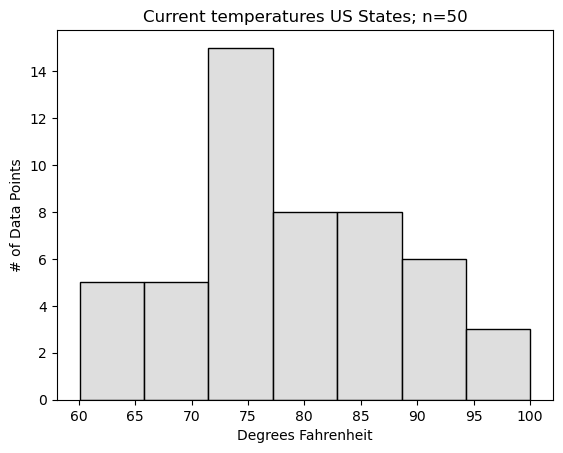

```python
sns.histplot(map_data_current["temp"],kde=False,color="lightgrey",edgecolor="black")
	plt.xlabel("Degrees Fahrenheit")
	plt.ylabel("# of Data Points")
	plt.title("Current temperatures US States; n=50")
```

```python
fig = go.Figure()
	fig.add_trace(go.Choropleth(
						locations=map_data_current["state"],
						locationmode="USA-states",
						name="",
						z=map_data_current['temp']))
	fig.add_trace(go.Scattergeo(
						lat=map_data_current["lon"],
						lon=map_data_current["lat"],
						mode="markers",
						name="",
						marker_color="white"))
	fig.update_layout(autosize=True,
						height=650,
						width=900,
						title = 'Current temperature US States in Fahrenheit at: '+map_data_current['timestamp'][0],
						geo=dict(scope='usa'))
	fig
```

[interactive chart not shown]

The a heat map inidcates the current temperatures across the United States. The map uses a color gradient to represent temperature ranges, with purple indicating lower temperatures (around 65°F) and yellow indicating higher temperatures (up to 100°F). The map shows a clear regional temperature distribution, with the western and northeastern parts of the country experiencing cooler temperatures (purple and blue shades), while the central and southeastern regions are warmer (orange and yellow shades). White dots scattered across the map likely represent specific temperature measurement points. This visualization provides a snapshot of temperature variations across the US at a given time.

**Timeseries of Monthly Average Temperatures for each US State**

Here we show the historical patterns for every pseudotemperature available from 1895 in timeseries. Some locations have all data avaible. Most locations are accounted for after 1960s

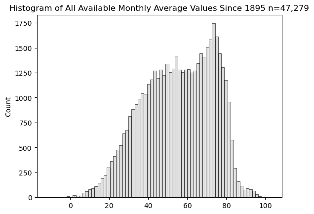

```python
sns.histplot(vals,kde=False,color="lightgrey",line_kws={'color':"black"})
	#plt.yscale('log')
	plt.title("Histogram of All Available Monthly Average Values Since 1895 n=47,279")
```

The histogram depicts the distribution of monthly average temperature values from 1895 onwards. The x-axis represents the temperature in degrees Fahrenheit, ranging from 0 to 100°F, while the y-axis shows the count of temperature occurrences. The histogram displays a bell-shaped distribution, with most temperatures falling between 40°F and 80°F. The peak of the distribution occurs around 70°F, indicating that this temperature range has the highest frequency. The count gradually decreases towards the lower and higher ends of the temperature spectrum, suggesting fewer occurrences of extreme temperatures. Overall, the histogram provides a comprehensive overview of historical temperature data, highlighting the most common monthly average temperatures over the specified period.

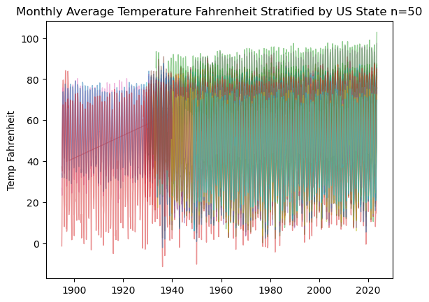

```python
#plt.figure(figsize=(34,3))
	for i in ports:
	   sns.lineplot(pd.to_numeric(historical_data[i[1]][~pd.isnull(historical_data[i[1]])]),linewidth=1,alpha=.5)
	plt.title("Monthly Average Temperature Fahrenheit Stratified by US State n=50")
	plt.ylabel("Temp Fahrenheit")
```

Addition of an average US temp line w/ regression.For this project we will be computing US monthly avg temperature as the mean of available average temperatures at the timepoint

```python
averages=[]
	for i in range(len(rows)):
	  timepoint = historical_data.iloc[[i]].values[0]
	  time=[float(j) for j in timepoint if pd.isnull(j)==False]
	  averages.append(sum(time)/len(time))
	averages_df = pd.DataFrame(index=rows)
	averages_df['averages']=averages
	averages_df
	averages_df.index = pd.to_datetime(averages_df.index)

	averages_df
```

|  | averages |
| --- | --- |
| 1895-01-01 | 24.160000 |
| 1895-02-01 | 25.052500 |
| 1895-03-01 | 42.130000 |
| 1895-04-01 | 56.067500 |
| 1895-05-01 | 61.892500 |
| ... | ... |
| 2023-03-01 | 45.029388 |
| 2023-04-01 | 55.845510 |
| 2023-05-01 | 65.336531 |
| 2023-06-01 | 72.242653 |
| 2023-07-01 | 78.820204 |

1543 rows × 1 columns

Now that we have the average of monthly average temperatures in the US we will try to predict future data. First, split the average averages datast into train and test

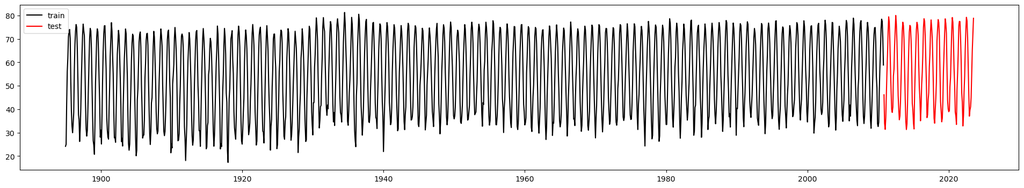

```python
plt.figure(figsize=(24,4))
	train = averages_df[averages_df.index < pd.to_datetime("2010-11-01", format='%Y-%m-%d')]
	train
	test = averages_df[averages_df.index >= pd.to_datetime("2010-11-01", format='%Y-%m-%d')]
	test
	plt.plot(train['averages'], color = "black",label="train")
	plt.plot(test['averages'], color = "red",label="test")
	plt.legend()
```

We want to see if a linear model can predict future data. In order to use dates in a model we need to transform them to **Ordinal Date** which is a numeric representation of date. To achieve this we will transform datetime objects with datetime.toordinal()

```python
averages_df["date"] = averages_df.index

	averages_df['ordinal_date']= pd.to_datetime(averages_df['date'])
	averages_df['ordinal_date']=averages_df['ordinal_date'].apply(lambda x: x.toordinal())

	averages_df
```

|  | averages | date | ordinal_date |
| --- | --- | --- | --- |
| 1895-01-01 | 24.160000 | 1895-01-01 | 691770 |
| 1895-02-01 | 25.052500 | 1895-02-01 | 691801 |
| 1895-03-01 | 42.130000 | 1895-03-01 | 691829 |
| 1895-04-01 | 56.067500 | 1895-04-01 | 691860 |
| 1895-05-01 | 61.892500 | 1895-05-01 | 691890 |
| ... | ... | ... | ... |
| 2023-03-01 | 45.029388 | 2023-03-01 | 738580 |
| 2023-04-01 | 55.845510 | 2023-04-01 | 738611 |
| 2023-05-01 | 65.336531 | 2023-05-01 | 738641 |
| 2023-06-01 | 72.242653 | 2023-06-01 | 738672 |
| 2023-07-01 | 78.820204 | 2023-07-01 | 738702 |

1543 rows × 3 columns

Now we will use the averages and the ordinal dates as input to the model

Predict future values using linear regression

```python
slope_h, intercept_h, r_h, p_h, std_err_h = stats.linregress(averages_df['ordinal_date'],averages_df['averages'])

	def myfunc_h(x):
		return slope_h * x + intercept_h

	y_pred_df_lm = pd.DataFrame(index=test.index)
	y_pred_df_lm["date"] = y_pred_df_lm.index
	y_pred_df_lm['date']= pd.to_datetime(y_pred_df_lm['date'])
	y_pred_df_lm['ordinal_date']=y_pred_df_lm['date'].apply(lambda x: x.toordinal())

	y_pred_df_lm['prediction']=y_pred_df_lm['ordinal_date'].apply(lambda x: myfunc_h(x))
	y_pred_df_lm

	linear_regression_rmse = np.sqrt(mean_squared_error(test["averages"].values, y_pred_df_lm["prediction"]))
	print("RMSE: ",linear_regression_rmse)
	print("slope:",slope_h)
```

```
RMSE:  15.27092511726122
	slope: 0.0001406182661936425
```

Since the linear regression is not performing great we seek out another solution. Autoregressive models predict future values from past data. In this example we use past temperature averages to forecast future averages

```python
model = ARIMA(train['averages'], order=(1,1,1),seasonal_order=(1,1,1,12))
	model_fit = model.fit()
```

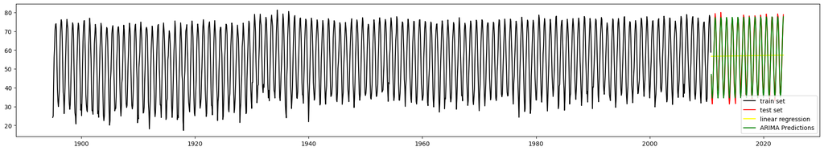

```python
plt.figure(figsize=(24,4))

	y_pred = model_fit.get_forecast(len(test.index))
	y_pred_df = y_pred.conf_int(alpha = 0.05)
	y_pred_df["Predictions"] = model_fit.predict(start = y_pred_df.index[0], end = y_pred_df.index[-1])
	y_pred_df.index = test.index
	y_pred_out = y_pred_df["Predictions"]
	plt.plot(train['averages'], color = "black",label= 'train set')
	plt.plot(test['averages'], color = "red",label= "test set")
	plt.plot(y_pred_df_lm['prediction'], color='yellow', label = 'linear regression')
	plt.plot(y_pred_out, color='green', label = 'ARIMA Predictions')

	plt.legend()
```

```python
#we show that we can fit a better model and decrease the RMSE with the Autoregression model compared to linear regression
	arma_rmse = np.sqrt(mean_squared_error(test["averages"].values, y_pred_df["Predictions"]))
	print("RMSE: ",arma_rmse)
```

```
RMSE:  2.2812186810309716
```

Model predictions:

"Predicted monthly average temperature in US 1970, 2150, and 2250"

```python
s1 = pd.to_datetime("1970-1-01", format='%Y-%m-%d')
	e1 = pd.to_datetime("1970-12-01", format='%Y-%m-%d')
	print(model_fit.predict(start=s1, end=e1))

	s = pd.to_datetime("2150-1-01", format='%Y-%m-%d')
	e = pd.to_datetime("2150-12-01", format='%Y-%m-%d')
	print(model_fit.predict(start=s, end=e))

	s3 = pd.to_datetime("2250-1-01", format='%Y-%m-%d')
	e3 = pd.to_datetime("2250-12-01", format='%Y-%m-%d')
	print(model_fit.predict(start=s3, end=e3))
```

```
1970-01-01    31.681011
	1970-02-01    33.872073
	1970-03-01    42.572465
	1970-04-01    53.095679
	1970-05-01    62.350186
	1970-06-01    70.948309
	1970-07-01    75.477208
	1970-08-01    74.027748
	1970-09-01    67.096961
	1970-10-01    56.878593
	1970-11-01    44.644538
	1970-12-01    35.037239
	Freq: MS, Name: predicted_mean, dtype: float64
	2150-01-01    39.977354
	2150-02-01    43.014572
	2150-03-01    51.465119
	2150-04-01    60.819545
	2150-05-01    69.809393
	2150-06-01    78.281231
	2150-07-01    82.799590
	2150-08-01    81.683886
	2150-09-01    74.451104
	2150-10-01    63.029776
	2150-11-01    52.453464
	2150-12-01    42.634329
	Freq: MS, Name: predicted_mean, dtype: float64
	2250-01-01    43.940857
	2250-02-01    46.978075
	2250-03-01    55.428623
	2250-04-01    64.783048
	2250-05-01    73.772896
	2250-06-01    82.244734
	2250-07-01    86.763093
	2250-08-01    85.647389
	2250-09-01    78.414607
	2250-10-01    66.993279
	2250-11-01    56.416967
	2250-12-01    46.597832
	Freq: MS, Name: predicted_mean, dtype: float64
```

## **3. Monthly Climate change in Philadelphia from 1895 to 2023**

```python
#print(new_average_data_Phila['AverageUpperLimit'])

	print("For example, the maximum average temperature of August is ")
	print(new_average_data_Phila['AverageUpperLimit']['aug'], "degree F")
```

```
For example, the maximum average temperature of August is
	81.3 degree F
```

```python
print("For example, the minimum average temperature of August is ")
	print(new_average_data_Phila['AverageLowerLimit']['aug'],"degree F")
```

```
For example, the minimum average temperature of August is
	70.2 degree F
```

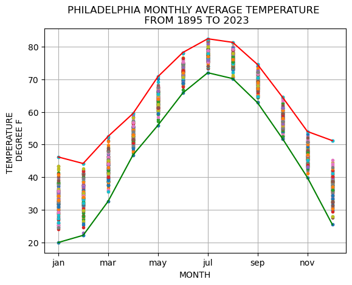

```python
new_average_data_Phila.plot(legend=None, marker='.', linestyle='none', title='PHILADELPHIA MONTHLY AVERAGE TEMPERATURE \n FROM 1895 TO 2023')
	new_average_data_Phila['AverageUpperLimit'].plot(color="red")
	new_average_data_Phila['AverageLowerLimit'].plot(color="green")
	plt.rcParams["figure.figsize"] = [8.6, 6.8]
	plt.rcParams["figure.autolayout"] = True
	plt.xlabel("MONTH")
	plt.ylabel("TEMPERATURE \n DEGREE F")
	plt.grid()
	plt.show()
```

Theline graph indicates Philadelphia Monthly Average Temperature from 1895 to 2023. The X-axis represents the months from January to December, while the Y-axis represents the temperature in degrees Fahrenheit, ranging from 20°F to 80°F. The graph displays two prominent lines: a red line indicating the upper limit (maximum average temperature) and a green line indicating the lower limit (minimum average temperature) for each month. The temperature data points for each year are shown as colored dots along these lines, illustrating the range and distribution of average temperatures. For instance, in August, the average temperature ranges from about 70.2°F to 81.3°F. This visualization highlights the historical monthly average temperature variations in Philadelphia over the years.

```python
print("For example, the minimum upper limit  temperature of August is ")
	print(new_min_data_Phila['MinUpperLimit']['aug'], "degree F")
```

```
For example, the minimum upper limit  temperature of August is
	65.0 degree F
```

```python
print("For example, the minimum lower limit temperature of August is ")
	print(new_min_data_Phila['MinLowerLimit']['aug'], "degree F")
```

```
For example, the minimum lower limit temperature of August is
	44.0 degree F
```

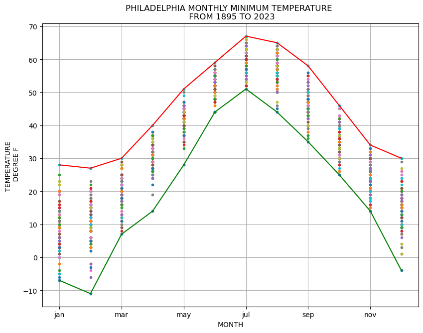

```python
new_min_data_Phila.plot(legend=None, marker='.', linestyle='none', title='PHILADELPHIA MONTHLY MINIMUM TEMPERATURE \n FROM 1895 TO 2023')
	new_min_data_Phila['MinUpperLimit'].plot(color="red")
	new_min_data_Phila['MinLowerLimit'].plot(color="green")
	plt.rcParams["figure.figsize"] = [8.6, 6.8]
	plt.rcParams["figure.autolayout"] = True
	plt.xlabel("MONTH")
	plt.ylabel("TEMPERATURE \n DEGREE F")
	plt.grid()
	plt.show()
```

The line chart showing the historical monthly minimum temperatures in Philadelphia from 1895 to 2023. The x-axis represents the months of the year, from January to December, while the y-axis shows the temperature in degrees Fahrenheit, ranging from -10°F to 70°F. The red line represents the upper limit of the minimum temperatures recorded each month, and the green line represents the lower limit. The colored dots scattered along each month indicate individual data points for the minimum temperatures over the years. This chart helps visualize the range and variability of the monthly minimum temperatures, with noticeable increases during the summer months (June to August) and decreases during the winter months (December to February). The spread of the dots indicates the variability in minimum temperatures for each month over the long historical period.

```python
print("For example, the Maximum Upper Limit temperature of August is ")
	print(new_max_data_Phila['MaxUpperLimit']['aug'],"degree F")
```

```
For example, the Maximum Upper Limit temperature of August is
	106.0 degree F
```

```python
print("For example, the Maximum Lower Limit temperature of August is ")
	print(new_max_data_Phila['MaxLowerLimit']['aug'],"degree F")
```

```
For example, the Maximum Lower Limit temperature of August is
	85.0 degree F
```

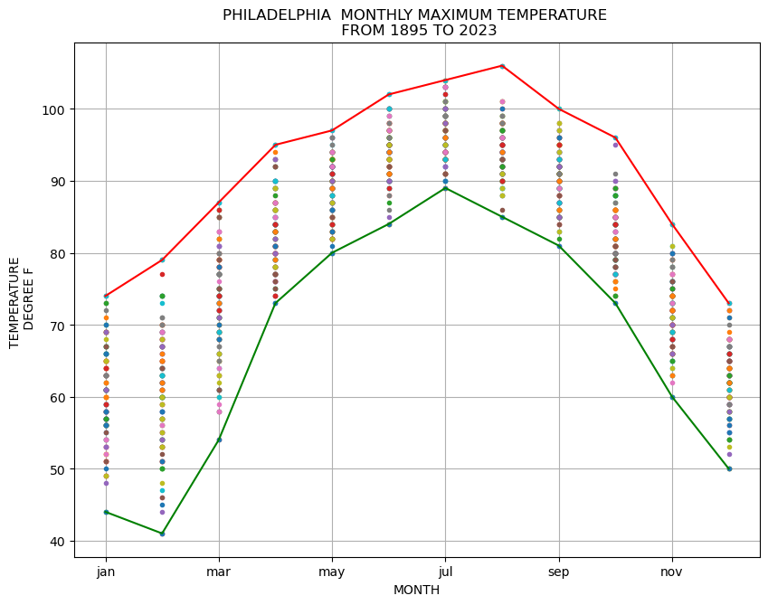

```python
new_max_data_Phila.plot(legend=None, marker='.', linestyle='none', title='PHILADELPHIA  MONTHLY MAXIMUM TEMPERATURE \n FROM 1895 TO 2023')
	new_max_data_Phila['MaxUpperLimit'].plot(color="red")
	new_max_data_Phila['MaxLowerLimit'].plot(color="green")
	plt.rcParams["figure.figsize"] = [8.6, 6.8]
	plt.rcParams["figure.autolayout"] = True
	plt.xlabel("MONTH")
	plt.ylabel("TEMPERATURE \n DEGREE F")
	plt.grid()
	plt.show()
```

The line chart illustrates the historical monthly maximum temperatures in Philadelphia from 1895 to 2023. The x-axis represents the months of the year, from January to December, and the y-axis indicates the temperature in degrees Fahrenheit, ranging from 40°F to 110°F. The red line shows the upper limit of the maximum temperatures recorded each month, while the green line displays the lower limit. Colored dots represent individual data points for the maximum temperatures over the years. This chart visually demonstrates the range and variability of the monthly maximum temperatures, with the highest temperatures occurring during the summer months (June to August) and the lowest during the winter months (December to February). The dispersion of the dots indicates the variation in maximum temperatures for each month throughout the long historical period, highlighting the broader range of maximum temperatures compared to minimum temperatures.

In the plot below, we present all calculated data from the minimum, maximum, and average temperature datasets as previously discussed. The red line represents the maximum temperature for each month, the green line represents the minimum temperature, and the yellow line represents the average temperature. This combined data visualization demonstrates the wide range of temperatures for each month. Based on these calculations, we can predict that the overall temperature in Philadelphia in August will be 76°F, although it can fluctuate widely from 44°F to 106°F.

```python
print("The Maximum temperature of August is ")
	print(month_Phila['MaxUpperLimit']['aug'],"degree F")
	print("The Average temperature of August is ")
	print(month_Phila['AverageAverageLimit']['aug'],"degree F")
	print("The Minimum temperature of August is ")
	print(month_Phila['MinLowerLimit']['aug'],"degree F")
```

```
The Maximum temperature of August is
	106.0 degree F
	The Average temperature of August is
	76.0 degree F
	The Minimum temperature of August is
	44.0 degree F
```

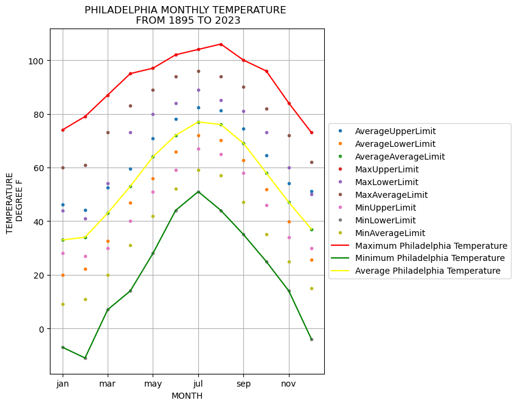

```python
month_Phila.plot(legend=None, marker='.', linestyle='none', title='PHILADELPHIA MONTHLY TEMPERATURE \n FROM 1895 TO 2023',label="")
	month_Phila['MaxUpperLimit'].plot(color="red",label ='Maximum Philadelphia Temperature')
	month_Phila['MinLowerLimit'].plot(color="green",label ='Minimum Philadelphia Temperature')
	month_Phila['AverageAverageLimit'].plot(color="yellow", label ='Average Philadelphia Temperature')
	plt.rcParams["figure.figsize"] = [8.6, 6.8]
	plt.rcParams["figure.autolayout"] = True
	plt.xlabel("MONTH")
	plt.ylabel("TEMPERATURE \n DEGREE F")
	plt.legend(loc='center left', bbox_to_anchor=(1, 0.5))
	plt.grid()
	plt.show()
```

The plot displays the calculated data from the minimum, maximum, and average temperature datasets for Philadelphia from 1895 to 2023. The red line represents the maximum temperatures for each month, the green line shows the minimum temperatures, and the yellow line indicates the average temperatures. This combined visualization demonstrates the wide range of temperatures for each month. The scatter points show the upper and lower limits and the average limits for each temperature dataset. For example, the overall average temperature in August is predicted to be 76°F, but the temperature can range from as low as 44°F to as high as 106°F. This comprehensive data presentation helps in understanding the historical temperature variations and trends over the years.

## **4. Yearly Climate change in Philadelphia from 1895 to 2023**

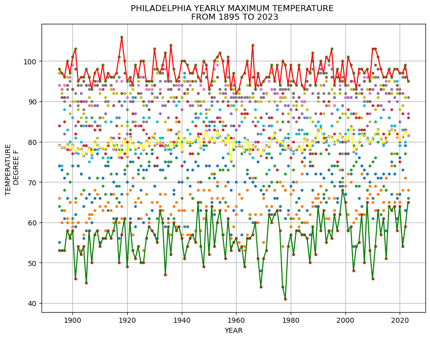

```python
#max_data_Phila = max_data_Phila.assign(MaxUpperLimit=max_data_Phila.max(axis=1),MaxLowerLimit=max_data_Phila.min(axis=1),MaxAverageLimit=round(max_data_Phila.mean(axis=1),1))
	max_data_Phila.plot(legend=None, marker='.', linestyle='none', title='PHILADELPHIA YEARLY MAXIMUM TEMPERATURE \n FROM 1895 TO 2023')
	max_data_Phila['MaxUpperLimit'].plot(color="red")
	max_data_Phila['MaxLowerLimit'].plot(color="green")
	max_data_Phila['MaxAverageLimit'].plot(color="yellow")
	plt.xlabel("YEAR")
	plt.ylabel("TEMPERATURE \n DEGREE F")
	plt.grid()
	plt.show()
```

We investigate time to calculate the overall yearly minimum temperature of Philadelphia in time series from 1895 to 2023. According to plot below, The plot presents the yearly minimum temperatures in Philadelphia from 1895 to 2023. The red line represents the maximum upper limit of minimum temperatures, consistently around 60°F. The yellow line indicates the average minimum temperature, showing a slight upward trend from about 30°F to above 35°F. The green line shows the minimum lower limit, which has increased from below 0°F to approximately 10°F. The scattered points illustrate the yearly distribution of minimum temperatures, highlighting the fluctuations and trends over time. This visualization provides a comprehensive overview of how the minimum temperatures in Philadelphia have changed over the past century.

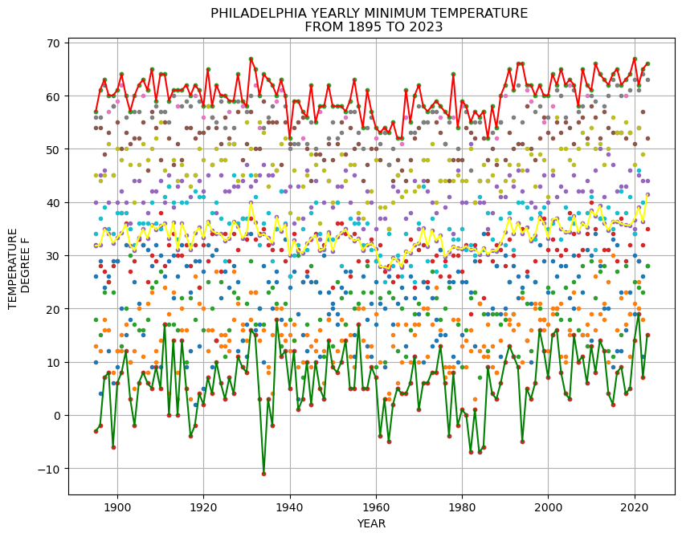

```python
#min_data_Phila = min_data_Phila.assign(MinUpperLimit=min_data_Phila.max(axis=1),MinLowerLimit=min_data_Phila.min(axis=1),MinAverageLimit=round(min_data_Phila.mean(axis=1),1))
	min_data_Phila.plot(legend=None, marker='.', linestyle='none', title='PHILADELPHIA YEARLY MINIMUM TEMPERATURE \n FROM 1895 TO 2023')
	min_data_Phila['MinUpperLimit'].plot(color="red")
	min_data_Phila['MinLowerLimit'].plot(color="green")
	min_data_Phila['MinAverageLimit'].plot(color="yellow")
	plt.xlabel("YEAR")
	plt.ylabel("TEMPERATURE \n DEGREE F")
	plt.grid()
	plt.show()
```

We also investigate time to calculate the overall yearly average temperature of Philadelphia in time series from 1895 to 2023. According to plot below,The plot illustrates the yearly average temperatures in Philadelphia from 1895 to 2023. The red line denotes the upper limit of the maximum average temperatures, consistently hovering around 80°F. The yellow line represents the average yearly temperature, which shows a slight increasing trend from around 55°F to 60°F over the period. The green line indicates the lower limit of the minimum average temperatures, which has risen from below 30°F to approximately 40°F. The scatter points display the yearly temperature distribution, capturing the variability and trends over the past century. This comprehensive visualization highlights the gradual increase in average temperatures in Philadelphia, reflecting broader climatic changes over time.

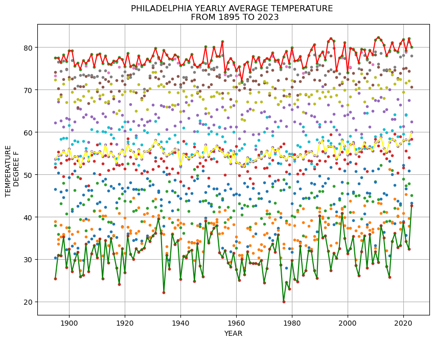

```python
#average_data_Phila = average_data_Phila.assign(AverageUpperLimit=average_data_Phila.max(axis=1),AverageLowerLimit=average_data_Phila.min(axis=1),AverageAverageLimit=round(average_data_Phila.mean(axis=1),1))
	average_data_Phila.plot(legend=None, marker='.', linestyle='none', title='PHILADELPHIA YEARLY AVERAGE TEMPERATURE \n FROM 1895 TO 2023')
	average_data_Phila['AverageUpperLimit'].plot(color="red")
	average_data_Phila['AverageLowerLimit'].plot(color="green")
	average_data_Phila['AverageAverageLimit'].plot(color="yellow")
	plt.xlabel("YEAR")
	plt.ylabel("TEMPERATURE \n DEGREE F")
	plt.grid()
	plt.show()
```

By combining the three datasets, we observed overlapping temperature data points in Philadelphia from 1895 to 2023. Maximum Average Temperature and Average Upper Limit Temperature overlap between 70 to 85°F, while Average Temperature, Minimum Upper Limit Temperature, and Maximum Lower Limit Temperature overlap between 50 to 65°F. Minimum Average Temperature and Average Lower Limit Temperature overlap between 20 to 45°F. The Maximum Temperature (95 to 105°F) and Minimum Temperature (-10 to 20°F) do not overlap with other ranges. The plot below illustrates yearly temperature trends, showing consistent maximum temperatures around 100°F, maximum average temperatures around 80°F, average temperatures around 55°F, and minimum temperatures fluctuating between 0°F and 20°F. This visualization highlights the broad range of temperature fluctuations and trends, capturing both extremes and average conditions in Philadelphia's climate.

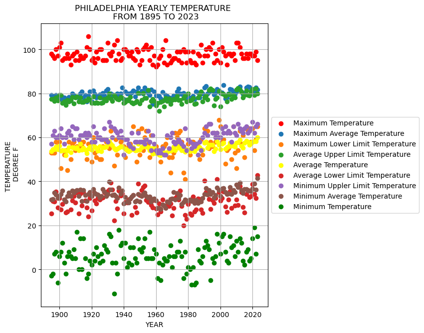

```python
x = list(average_data_Phila.T.head(0))
	y = list(average_data_Phila['AverageAverageLimit'])
	yMin = list(min_data_Phila['MinLowerLimit'])
	yMax = list(max_data_Phila['MaxUpperLimit'])

	plt.scatter(x, yMax, label ='Maximum Temperature', color="red")
	plt.scatter(x, list(max_data_Phila['MaxAverageLimit']), label ='Maximum Average Temperature')
	plt.scatter(x, list(max_data_Phila['MaxLowerLimit']), label ='Maximum Lower Limit Temperature')
	plt.scatter(x, list(average_data_Phila['AverageUpperLimit']), label ='Average Upper Limit Temperature')
	plt.scatter(x, y, label ='Average Temperature', color = "yellow")
	plt.scatter(x, list(average_data_Phila['AverageLowerLimit']), label ='Average Lower Limit Temperature')
	plt.scatter(x, list(min_data_Phila['MinUpperLimit']), label ='Minimum Uppler Limit Temperature')
	plt.scatter(x, list(min_data_Phila['MinAverageLimit']), label ='Minimum Average Temperature')
	plt.scatter(x, yMin, label ='Minimum Temperature', color="green")
	plt.xlabel("YEAR")
	plt.ylabel("TEMPERATURE \n DEGREE F")
	plt.legend(loc='center left', bbox_to_anchor=(1, 0.5))
	plt.title('PHILADELPHIA YEARLY TEMPERATURE \n FROM 1895 TO 2023')
	plt.grid()
	plt.show()
```

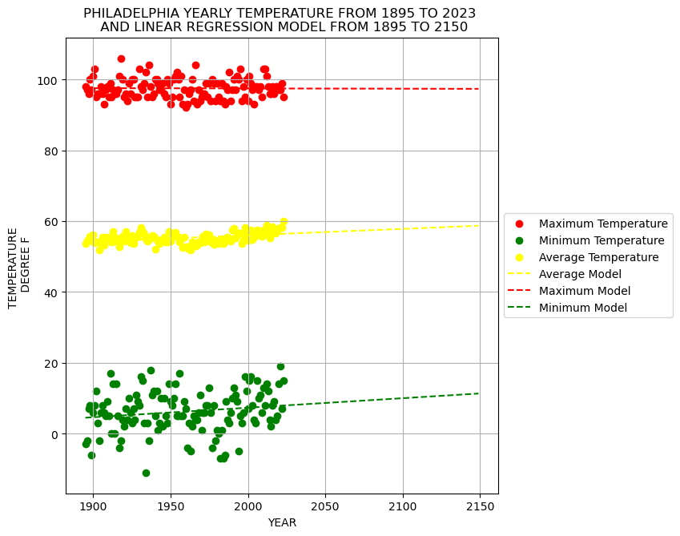

```
Our predicted average temperature for 2150 is:  58.71 degree F
	Our predicted maximum temperature for 2150 is:  97.34 degree F
	Our predicted minimum temperature for 2150 is:  11.35 degree F
```

```python
x = list(average_data_Phila.T.head(0))
	y = list(average_data_Phila['AverageAverageLimit'])
	yMin = list(min_data_Phila['MinLowerLimit'])
	yMax = list(max_data_Phila['MaxUpperLimit'])

	slope, intercept, r, p, std_err = stats.linregress(x, y)
	slopeMax, interceptMax, rMax, pMAx, std_err_Max = stats.linregress(x, yMax)
	slopeMin, interceptMin, rMin, pMin, std_err_Min = stats.linregress(x, yMin)
	def myfunc(x):
		return slope * x + intercept
	def myfuncMax(x):
		return slopeMax * x + interceptMax
	def myfuncMin(x):
	  return slopeMin * x + interceptMin

	x1 = list(range(1895,2150))

	mymodel = list(map(myfunc, x1))
	mymodelMax = list(map(myfuncMax, x1))
	mymodelMin = list(map(myfuncMin, x1))

	plt.scatter(x, yMax, label ='Maximum Temperature', color="red")
	plt.scatter(x, yMin, label ='Minimum Temperature', color="green")
	plt.scatter(x, y, label ='Average Temperature', color = "yellow")
	plt.plot(x1, mymodel,linestyle='dashed',color="yellow",label ='Average Model')
	plt.plot(x1, mymodelMax, linestyle='dashed',color="red",label ='Maximum Model')
	plt.plot(x1, mymodelMin, linestyle='dashed',color="green",label ='Minimum Model')
	plt.xlabel("YEAR")
	plt.ylabel("TEMPERATURE \n DEGREE F")
	plt.legend(loc='center left', bbox_to_anchor=(1, 0.5))
	plt.title('PHILADELPHIA YEARLY TEMPERATURE FROM 1895 TO 2023 \n AND LINEAR REGRESSION MODEL FROM 1895 TO 2150')
	plt.grid()
	plt.show()

	print("Our predicted average temperature for 2150 is: ",round(myfunc(2150),2), "degree F")
	print("Our predicted maximum temperature for 2150 is: ",round(myfuncMax(2150),2), "degree F")
	print("Our predicted minimum temperature for 2150 is: ",round(myfuncMin(2150),2), "degree F")
```

# **Limitation**

Initially, we had struggled with API access permission and subscription. We only request 1000 access per time for free account. However, we found NOAA and ACIS provided free API to load. Therefore, we can obtain the historical data in order to perform time series analysis from API.

# **A selection of data for continued analysis, including justification.**

For data selection, we competed the ACIS API and NOAA dataset. Both dataset had pro and cons. Like ACIS API, the disadvantage is too long loading time with large file size. Like NOAA API, the disadvantage is too condense information to analyze.

We think that a lot of this data could be used for continued analysis including temperatures, pressures, humidities. A continued analysis of this data would be interesting if there is a significant difference between values across selected locations. For example, a significant difference in temperature opens the doors to interesting questions like why is temperature different across locations? Building upon an observation and telling the story of why and how.

We also think how to combine both API and NOAA dataset together to get the good data source for us to analyze and develop an accurate weather application for US state and cities. It is a interesting project for us to build up our data interpretation and data analysis

# **Potential Audience**

1. All American who want an accurate weather prediction.
2. The people who have the concern of climate change in US
3. The researcher who need the data visualization for climate change in US
4. Weather professionals who's services rely on weather data. Meteorologist, weather consultants, climate analysts.

# **References**

https://openweathermap.org/api

https://openweathermap.org/current

https://climate.nasa.gov/ global temperature

https://climate.nasa.gov/news/3276/nasa-finds-june-2023-hottest-on-record/

https://drexel.edu/news/archive/2023/May/climate-resilience-research-agenda-for-greater-philadelphia#:~:text=CCRUN's%20data%20projects%20that%20for,of%2027%20days%20per%20year.